# Explorative data analysis and data visualization in R

Anika Liu - al862@cam.ac.uk Luca Stefanucci - ls760@cam.ac.uk

05 Feb 2020

## Index

#### Short introduction to R

#### Explore the data

#### Visualise dataset

#### Example

#### Practice

To fully enjoy the workshop, you should have:

- Basic knowledge of R/coding is preferable, but not essential
- Fully charged laptop or charger
- R and Rstudio already installed on your laptop
  - [Install R](https://cran.r-project.org/)
  - [Install Rstudio](https://rstudio.com/products/rstudio/download/#download)

## Short introduction to R

R is a free powerful **programming language** and **environment**. It provides most of the **statistical test**, either built-in or in packages. Moreover, it allows to produce publication-quality **graphs** (or graphics) accompaining the stats. One of the main reason why R is so widely use in statistics and data analysis is its data structure. It organises elements in **vectors** and allow to make orperations between them. Vectors are 1-dimension containers for elements that are all of the same type (i.e. logical, integer, double, character, complex or raw). Most likely, in real life problems, data will have a 2-dimesional or matrix-like structure, called **dataframe** in the R language.

Often paired with R, there is RStudio. Rstudio is a integrated development environment (IDE) developed fo R. When you open RStudio you are going to see 4 panels. The top-left panel is the **text editor** you can use this to write your script, test it to the console and save it. On the bottom-left, you have the **console**, it executes commands using the **R language as interpreter**, however you can’t save the script you run in teh console. Top right, you can see the environment/hisoty tab, when all the variables of this environment are stored and you have a history of the commands you have runned. Ultumately, in the bottom right panel you have the plots, helps.

**Markdown** is a way to transform plain text to a rich style text. It is a great way to share your codes. This text is written in markdown, have a look at the raw script.

Now let’s start with the course!

## Import the data

Firstly, let’s import the packages we are going to use for this workshop. Packages are sets of functions which you can download and they allow you to extend R basic functions. In this workshop we will mainly use “tidyverse”. Tidyverse is a collection of packages designed to mung and visualise data, key tasks in data science. For more info about Tidyverse go on: https://www.tidyverse.org/

For this workshop we will need the packages `tidyverse` and `reshape2`. Therefore we first install them (this has to be done only once):  
N.B. Remove the hash in your code to install them

```r
#install.packages('tidyverse')
#install.packages('reshape2')
```

Next, we load the packages into the current environment:

```r
library(tidyverse)
library(reshape2)
```

Secondly, we import the data set we want to work on. For this workshop, we selected some data publicly available at http://www-huber.embl.de/users/klaus/BasicR/bodyfat.rda. They are made available from Bernd Klaus (EMBL) and used as teaching material for a few R courses. You will find the data in the GitHub repository (“bodyfat.csv”).

```r
bd_fat_df <- read_csv("bodyfat.csv", col_names = TRUE)
# We import and store the data from the file "bodyfat.csv" in an R dataframe.
# We set col_names to TRUE in this case, as every column has a header and we want to keep it as column name.
```

Note that the data frame probably has data collected in U.S., so hight and weight units are in pound and inches.

To understand what a function is doing, how to use it and what variables it takes as input ? (e.g. ?read_csv) gives some information about the function and its grammar. help() has a similar use. For example:

```r
help(read_csv)
?read_csv
#Or for a broader search:
??read_csv
```

## Explore the data

It is a good practice to explore a bit your data before starting to work with them. It is helpful to understand what kind of data you are looking at, if there were any mistakes while importing them, if the dataset is “clean” or it needs some wrangling and so on.

Good functions to quickly explore your data frame are `dim()`, `summary()`, `head()`

```r
# To show the row and column number of the data frame use dim(). If you are expecting 2000 observations or 30 variables, then you might have spotted a mistake.
dim(bd_fat_df)
```

```
## [1] 251  15
```

```r
# Head is used to visualize the first 10 (in this case) lines of the dataframe
head(bd_fat_df, n = 10)
```

```
## # A tibble: 10 x 15
##    density percent.fat   age weight height neck.circum chest.circum
##      <dbl>       <dbl> <dbl>  <dbl>  <dbl>       <dbl>        <dbl>
##  1    1.07        12.3    23   154.   67.8        36.2         93.1
##  2    1.09         6.1    22   173.   72.2        38.5         93.6
##  3    1.04        25.3    22   154    66.2        34           95.8
##  4    1.08        10.4    26   185.   72.2        37.4        102.
##  5    1.03        28.7    24   184.   71.2        34.4         97.3
##  6    1.05        20.9    24   210.   74.8        39          104.
##  7    1.05        19.2    26   181    69.8        36.4        105.
##  8    1.07        12.4    25   176    72.5        37.8         99.6
##  9    1.09         4.1    25   191    74          38.1        101.
## 10    1.07        11.7    23   198.   73.5        42.1         99.6
## # … with 8 more variables: abdomen.circum <dbl>, hip.circum <dbl>,
## #   thigh.circum <dbl>, knee.circum <dbl>, ankle.circum <dbl>,
## #   bicep.circum <dbl>, forearm.circum <dbl>, wrist.circum <dbl>
```

```r
# Summary prints a short stats report of the data frame, one per column
summary(bd_fat_df)
```

```
##     density       percent.fat         age            weight
##  Min.   :0.995   Min.   : 0.00   Min.   :22.00   Min.   :118.5
##  1st Qu.:1.042   1st Qu.:12.45   1st Qu.:35.50   1st Qu.:158.8
##  Median :1.055   Median :19.20   Median :43.00   Median :176.2
##  Mean   :1.056   Mean   :19.10   Mean   :44.89   Mean   :178.8
##  3rd Qu.:1.070   3rd Qu.:25.25   3rd Qu.:54.00   3rd Qu.:196.9
##  Max.   :1.109   Max.   :47.50   Max.   :81.00   Max.   :363.1
##      height       neck.circum     chest.circum   abdomen.circum
##  Min.   :64.00   Min.   :31.10   Min.   : 79.3   Min.   : 69.40
##  1st Qu.:68.25   1st Qu.:36.40   1st Qu.: 94.3   1st Qu.: 84.55
##  Median :70.00   Median :38.00   Median : 99.6   Median : 90.90
##  Mean   :70.31   Mean   :38.00   Mean   :100.8   Mean   : 92.51
##  3rd Qu.:72.25   3rd Qu.:39.45   3rd Qu.:105.3   3rd Qu.: 99.20
##  Max.   :77.75   Max.   :51.20   Max.   :136.2   Max.   :148.10
##    hip.circum      thigh.circum    knee.circum     ankle.circum
##  Min.   : 85.00   Min.   :47.20   Min.   :33.00   Min.   :19.1
##  1st Qu.: 95.50   1st Qu.:56.00   1st Qu.:36.95   1st Qu.:22.0
##  Median : 99.30   Median :59.00   Median :38.50   Median :22.8
##  Mean   : 99.84   Mean   :59.36   Mean   :38.57   Mean   :23.1
##  3rd Qu.:103.35   3rd Qu.:62.30   3rd Qu.:39.90   3rd Qu.:24.0
##  Max.   :147.70   Max.   :87.30   Max.   :49.10   Max.   :33.9
##   bicep.circum   forearm.circum   wrist.circum
##  Min.   :24.80   Min.   :21.00   Min.   :15.80
##  1st Qu.:30.20   1st Qu.:27.30   1st Qu.:17.60
##  Median :32.00   Median :28.70   Median :18.30
##  Mean   :32.27   Mean   :28.66   Mean   :18.23
##  3rd Qu.:34.35   3rd Qu.:30.00   3rd Qu.:18.80
##  Max.   :45.00   Max.   :34.90   Max.   :21.40
```

## Subset the data set

Quite often datasets can grow very big, slowing down all the analysis. So, in these cases it might be handy to take only a part of the dataset. It may be also useful to have a subset of the dataset when you need to check a new script or to create a training dataset (in this last case the subset would be made in a different way).

Let’s say we are just interested in people over 40 y.o. and it doesn’t make much sense to have the entire dataset in our analysis. How could we subset the dataframe?

```r
# To have only those rows that have matching conditions, we can use the filter() function, which is a function of the Tidyverse/dplyr package.
# In this case, filter asks to return only the rows which have a value over 40 in the column age. We store it in another variable, a new dataframe, called "bd_fat_df40"

bd_fat_df40 <- bd_fat_df %>%
               filter(age > 40 )

# N.B.: In R you can use numbers and some special caracters in the variable name, but not at the beginning of the variable name
```

`%>%` this symbol is called “pipe”. It is a useful way to pass information from one function to the following one. In the previous case I asked to read the bd_fat_df and then to filter out the rows that have a value in the column “age” of 40 y.o. or below.

**Question:** Have a look at the filter function grammar. How could you have the same result without piping?

```r
# We can also subset according to more than 1 criteria. In this case we ask to return a dataframe of people older than 40 y.o. and taller than 70 inches. To use more than one filter we use Boolean operator AND or OR. (More info here: https://www.datamentor.io/r-programming/operator/)

# AND
bd_fat_df_age_AND_heigth <- bd_fat_df %>%
                       filter(age > 40 & height > 70.00)
# OR
bd_fat_df_age_OR_heigth <- bd_fat_df %>%
                       filter(age > 40 | height > 70.00)
```

Sometimes it is convenient to create another observation in the data frame which is derived from one or more observations already in the data set. We can use the mutate function to do this. You can use mutate also for a series of other things (e.g change the class attribute of a vector)

By now, you should be able to check out the `mutate()` funtion documentation. Have a look at it.

```r
bd_fat_df_BMI <- bd_fat_df_age_OR_heigth %>%
  # mutate here is used to calculate the BMI and add it as a new column to the data frame
                 mutate(BMI = (weight/height^2) * 703 ) %>%
  # re-order the data.frame columns as we want. everything() is used to call all the columns which haven't been called before
                 select(age, height, weight, BMI, density, percent.fat, everything()) %>%
  # this command will sort the data frame columns according to the descending BMI order.
  # arrange is reframing the dataframe and desc() is asking to sort them in an descending order.
                 arrange(desc(BMI))
```

## Look at the data by groups

One of the strengths of R is the possibility to perform vector operations, such as arithmetics operations or indexes operations. However, sometimes one wants to perform operations just for a sub-group of a vector. This may be particularly useful for categorical variables. A categarical variable, usually, describes a feature of the data and most of the time one wants to preserve these information when performing operations. In this case, group_by (and all its derived functions) can help us in this task.

```r
# group_by divides the vector, or the table, in groups defined by one or more variables and performs the operation by these so-defined groups
bd_fat_df_BMI %>%
      group_by(height <= quantile(height)[3], height > quantile(height)[3]) # here we divide the dataset according to the heights. We will have 2 subgroups having the top 50% heights and the bottom 50% heights
```

```
## # A tibble: 210 x 18
## # Groups:   height <= quantile(height)[3], height > quantile(height)[3] [2]
##      age height weight   BMI density percent.fat neck.circum chest.circum
##    <dbl>  <dbl>  <dbl> <dbl>   <dbl>       <dbl>       <dbl>        <dbl>
##  1    46   72.2   363.  48.9   1.02         35.2        51.2         136.
##  2    45   68.8   263.  39.1   1.02         34.5        43.2         128.
##  3    51   64     219   37.6   0.995        47.5        41.2         120.
##  4    65   68.2   224.  33.9   1.02         35          38.8         120.
##  5    37   71.5   241.  33.2   1.03         29.9        42.1         119.
##  6    44   69.8   223   32.2   1.02         34.8        40.9         122.
##  7    41   73.5   247.  32.2   1.03         32.3        42.1         117
##  8    49   65     192.  31.9   1.01         40.1        38.4         118.
##  9    63   69.5   219.  31.9   1.04         27.3        40.2         118.
## 10    50   67     203   31.8   1.03         32.6        40.2         115.
## # … with 200 more rows, and 10 more variables: abdomen.circum <dbl>,
## #   hip.circum <dbl>, thigh.circum <dbl>, knee.circum <dbl>,
## #   ankle.circum <dbl>, bicep.circum <dbl>, forearm.circum <dbl>,
## #   wrist.circum <dbl>, `height <= quantile(height)[3]` <lgl>, `height >
## #   quantile(height)[3]` <lgl>
```

```r
#In this example, group_by creates a new logical-class column which has TRUE where the requirement is satisfied.
```

Often used together with `group_by()` is the `summarise()` fuction, it allows to perform group-wise operations.

```r
# We could run summarise on our entire dataset (without group filters).
bd_fat_df_BMI %>% summarise(mean = mean(height), sd = sd(height), mean_BMI = mean(BMI))
```

```
## # A tibble: 1 x 3
##    mean    sd mean_BMI
##   <dbl> <dbl>    <dbl>
## 1  70.7  2.64     25.6
```

```r
# however the results won't be much different from a normal function:
mean(bd_fat_df_BMI$height); sd(bd_fat_df_BMI$height); mean(bd_fat_df_BMI$BMI)
```

```
## [1] 70.6881
```

```
## [1] 2.643893
```

```
## [1] 25.58639
```

```r
# More useful is to run summarise after we've grouped our dataset. Here we are grouping according to the hight. Top 50% and bottom 50% to see if there are differences in the BMI
bd_fat_df_BMI %>%
      group_by(height <= quantile(height)[3], height > quantile(height)[3]) %>%
      summarise(mean_height = mean(height), sd_height = sd(height), mean_BMI = mean(BMI))
```

```
## # A tibble: 2 x 5
## # Groups:   height <= quantile(height)[3] [2]
##   `height <= quantile(hei… `height > quantile(he… mean_height sd_height mean_BMI
##   <lgl>                    <lgl>                        <dbl>     <dbl>    <dbl>
## 1 FALSE                    TRUE                          72.9      1.37     25.5
## 2 TRUE                     FALSE                         68.6      1.68     25.7
```

## Plot the data set

Now that we are happy with data frame structure and content we can start to plot some variables.

R has a lot of visualization packages, every one has some advantages or may be more helpful to some kind of plot then others. ggplot is a quite versatile package to visualize data, still part of the tidyverse. The strength of ggplot is in its grammar, which is standardized for all kinds of plots and allows the generation of publication-ready figures in a flexible manner. It is a layer function, which means you can keep on adding data ot it.

Let’s start with the basics and create an (empty) graphic with the ggplot function.

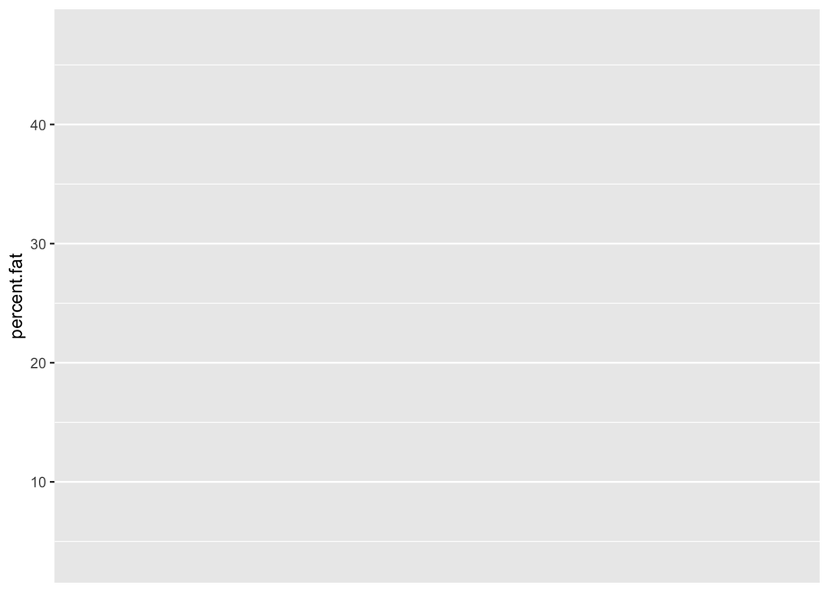

```r
plot_plain<-ggplot(bd_fat_df_BMI, mapping = aes( y = percent.fat))
#To look at the plot just call the variable:
plot_plain
```

As you can see the figure currently only contains the axes which are defined through the mapping aesthethics, but there is no actual plot. What if we want to know the distribution of percent.fat?

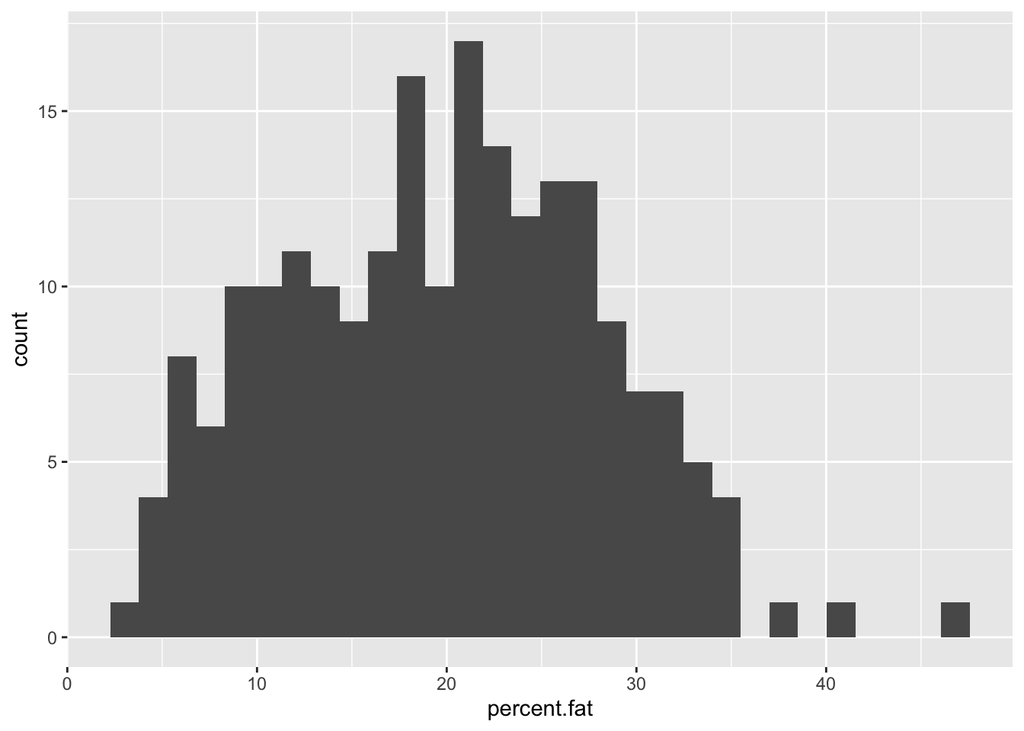

```r
#One continuous variable
plot_histogram<-ggplot(bd_fat_df_BMI, mapping = aes(percent.fat))+
  geom_histogram()
plot_histogram
```

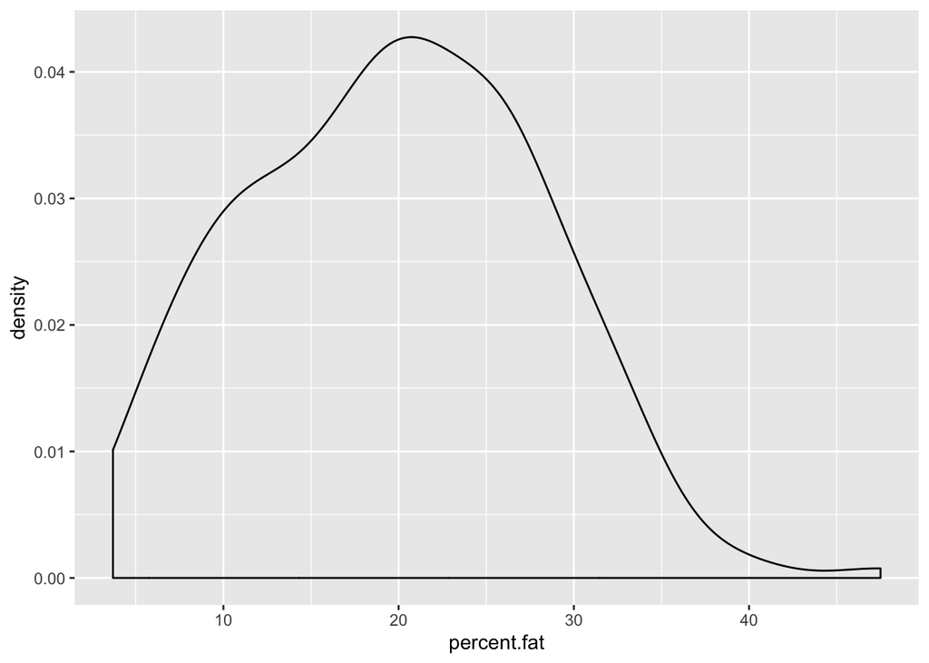

```r
plot_density<-ggplot(bd_fat_df_BMI, mapping = aes(percent.fat))+
  geom_density()
plot_density
```

There is a second group of functions whcih can be used which is defined thorugh one continuous and one dicrete variable. If you want to display the same distribution as above, just specify the discrete variable to a constant number.

The boxplot shows the quantiles and the median of the data. The qualtiles are dividing the data in top 25% and bottom 25%, the square has 50% of the entire dataset. Dots are the outliers. (The x axis in this case is not meaningful)

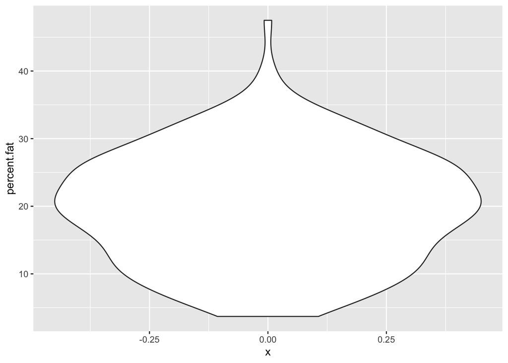

```r
#One continuous variable + one discrete variable

# Violin plot:
plot_violin<-ggplot(bd_fat_df_BMI, mapping = aes( y = percent.fat, x=0))+
  geom_violin()
plot_violin
```

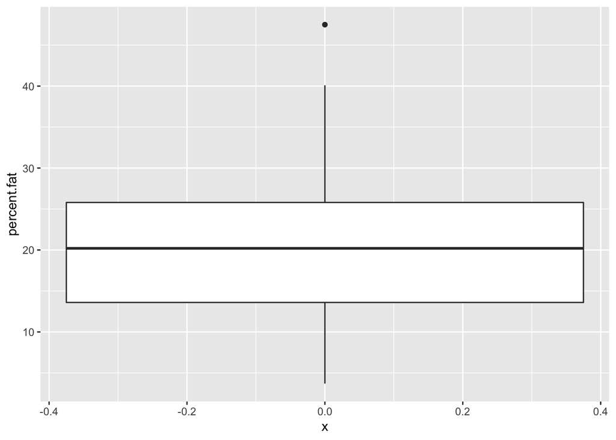

```r
# Boxplot
plot_box<-ggplot(bd_fat_df_BMI, mapping = aes( y = percent.fat, x=0))+
  geom_boxplot()
plot_box
```

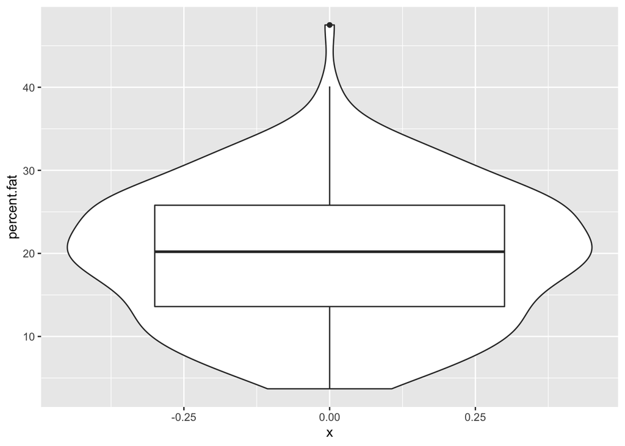

```r
# Or combine both:
plot_combine<-plot_violin+
  geom_boxplot(width=0.6)
plot_combine
```

**Question:** Let’s go back to the first part. Which command can you use to find out which values the boxplot quantile lines correspond to?